# Statcast Swing Mechanics and Contact Quality Analysis

##### How does swing path tilt relate to contact quality metrics such as sweet spot probability, hard-hit probability, and expected wOBA?

### 3.1 Data Selection and Cleaning

The dataset is retrieved from MLB website, containing detailed pitch-by-pitch tracking data, including swing metrics and batted-ball outcomes. For this analysis, we focus on batted-ball events with complete information on swing path tilt, launch characteristics, and pitch location.

```r
get_data <- function(start_date, end_date, season = 2025){
  url <- glue::glue(
  "https://baseballsavant.mlb.com/statcast_search/csv?all=true",
  "&game_date_gt={start_date}&game_date_lt={end_date}",
  "&player_type=batter&type=details"
  )
  readr::read_csv(
    url,
    show_col_types = FALSE,
    guess_max = 200000,
    col_types = readr::cols(
      swing_path_tilt                     = readr::col_double(),
      launch_speed                        = readr::col_double(),
      launch_angle                        = readr::col_double(),
      estimated_woba_using_speedangle     = readr::col_double(),
      plate_z                             = readr::col_double(),
      sz_bot                              = readr::col_double(),
      sz_top                              = readr::col_double(),
      .default = readr::col_character()
    )
  ) |>
    janitor::clean_names()
}

start  <- as.Date("2024-01-01")
end    <- as.Date("2025-11-10")
starts <- seq.Date(start, end, by = "month")
ends   <- pmin(c(starts[-1] - 1, end), end)

raw <- purrr::map2_dfr(starts, ends, ~ get_data(.x, .y)) |>
  suppressMessages(readr::type_convert(guess_max = Inf))

dat <-  raw |>
    dplyr::select(
      swing_path_tilt,
      launch_speed, launch_angle,
      estimated_woba_using_speedangle,
      plate_z, sz_bot, sz_top
    ) |>
    filter(
      !is.na(swing_path_tilt),
      !is.na(launch_speed),
      !is.na(launch_angle),
      !is.na(estimated_woba_using_speedangle)
    ) |>
    mutate(
      hard_hit = as.integer(launch_speed >= 95),
      sweet_spot = as.integer(launch_angle >= 8 & launch_angle <= 32)
    )
```

### 3.2 **EDA**

#### 3.2.1 Distribution of Key Variables

Descriptive statistics were computed to summarize distributions of swing-related variables and hitting outcomes.

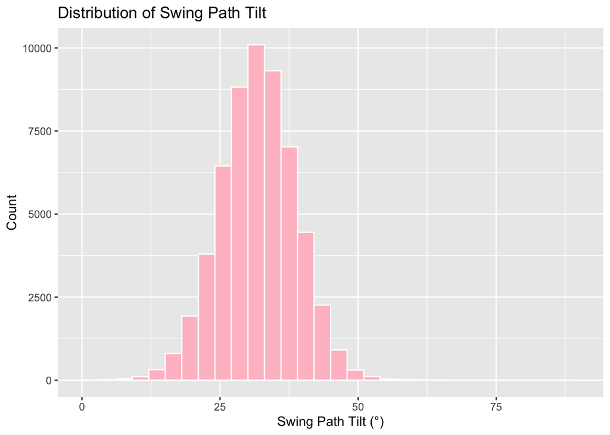

```r
ggplot(dat, aes(x = swing_path_tilt)) +
  geom_histogram(bins = 30, fill = "pink", color = "white") +
  labs(title = "Distribution of Swing Path Tilt", x = "Swing Path Tilt (°)", y = "Count")
```

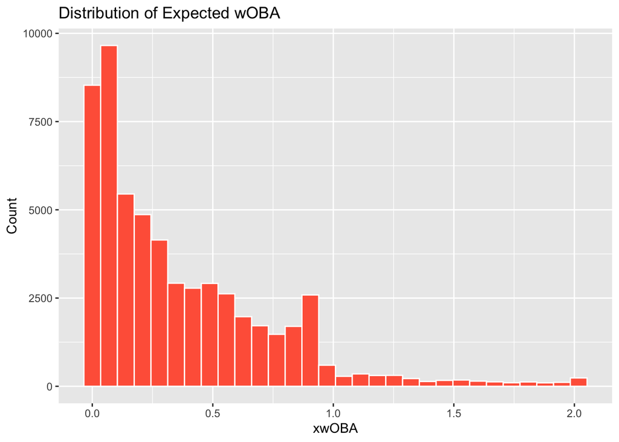

```r
ggplot(dat, aes(x = estimated_woba_using_speedangle)) +
  geom_histogram(bins = 30, fill = "tomato", color = "white") +
  labs(title = "Distribution of Expected wOBA", x = "xwOBA", y = "Count")
```

```r
mean(dat$hard_hit)
```

```
## [1] 0.3917711
```

```r
mean(dat$sweet_spot)
```

```
## [1] 0.3547973
```

#### 3.2.2 Swing Path Tilt vs. Contact Quality Outcomes

Exploratory visualizations were generated to examine the empirical relationship between swing path tilt and three key outcome measures:

- *Sweet Spot Rate* (probability of 8° ≤ launch angle ≤ 32°)
- *Hard–Hit Rate* (probability of exit velocity ≥ 95 mph)
- *Expected wOBA* (continuous measure of expected batting value)

Each metric was plotted against binned swing path tilt values to illustrate potential nonlinearity.

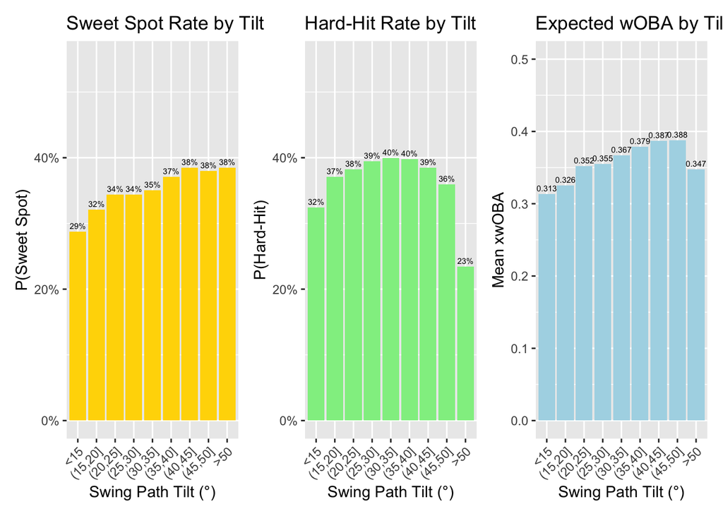

```r
quick_EDA <- function(){
  dat_bin <- dat |>
  mutate(tilt_bin = cut(
    swing_path_tilt,
    breaks = c(-Inf, 15, 20, 25, 30, 35, 40, 45, 50, Inf),
    right = TRUE,
    include.lowest = TRUE,
    labels = c("<15", "(15,20]", "(20,25]", "(25,30]", "(30,35]", "(35,40]", "(40,45]", "(45,50]", ">50")
  ))

  # Sweet Spot
  p1 <- dat_bin |>
    group_by(tilt_bin) |>
    summarise(p = mean(sweet_spot), .groups="drop") |>
    ggplot(aes(tilt_bin, p)) +
    geom_col(fill="gold") +
    geom_text(aes(label=scales::percent(p, accuracy = 1)), vjust=-0.5, color="black", size=2) +
    scale_y_continuous(labels=scales::percent_format(accuracy = 1), limits=c(0,0.55)) +
    labs(x="Swing Path Tilt (°)", y="P(Sweet Spot)",
         title="Sweet Spot Rate by Tilt") +
    theme(axis.text.x = element_text(angle=45, hjust=1))

  # Hard-Hit
  p2 <- dat_bin |>
    group_by(tilt_bin) |>
    summarise(p = mean(hard_hit), .groups="drop") |>
    ggplot(aes(tilt_bin, p)) +
    geom_col(fill="lightgreen") +
    geom_text(aes(label=scales::percent(p, accuracy = 1)), vjust=-0.5, color="black", size=2) +
    scale_y_continuous(labels=scales::percent_format(accuracy = 1), limits=c(0,0.55)) +
    labs(x="Swing Path Tilt (°)", y="P(Hard-Hit)",
         title="Hard-Hit Rate by Tilt") +
    theme(axis.text.x = element_text(angle=45, hjust=1))

  # xwOBA
  p3 <- dat_bin |>
    group_by(tilt_bin) |>
    summarise(xwoba = mean(estimated_woba_using_speedangle, na.rm = TRUE), .groups="drop") |>
    ggplot(aes(tilt_bin, xwoba)) +
    geom_col(fill="lightblue") +
    geom_text(aes(label=round(xwoba, 3)), vjust=-0.5, color="black", size=2) +
    scale_y_continuous(limits=c(0,0.5)) +
    labs(x="Swing Path Tilt (°)", y="Mean xwOBA",
         title="Expected wOBA by Tilt") +
    theme(axis.text.x = element_text(angle=45, hjust=1))

  (p1 | p2 | p3) + plot_layout(widths = c(1,1,1))
}
quick_EDA()
```

### 3.3 Models

Three models were built to evaluate how swing path tilt affects contact quality — both alone and interacting with pitch height (Low, Mid, High).

Each outcome (*Sweet Spot*, *Hard–Hit*, *Expected wOBA*) was modeled twice: first with tilt only, then with the interaction term to test whether the effect changes across pitch levels.

```r
dat <- dat |>
  mutate(rel_plate_z = (plate_z - sz_bot) / pmax(1e-6, (sz_top - sz_bot))) |>
  mutate(plate_z_bin = cut(rel_plate_z, breaks = c(-Inf, 0.3, 0.7, Inf),
                           labels = c("Low","Mid","High")))

pred_ci <- function(mod, newdata){
  if (inherits(mod, "glm")) {
    p <- predict(mod, newdata, se.fit = TRUE, type = "link")
    fit <- plogis(p$fit); lwr <- plogis(p$fit - 1.96*p$se.fit); upr <- plogis(p$fit + 1.96*p$se.fit)
  } else {
    p <- predict(mod, newdata, se.fit = TRUE)
    fit <- as.numeric(p$fit); lwr <- fit - 1.96*p$se.fit; upr <- fit + 1.96*p$se.fit
  }
  cbind(newdata, fit, lwr, upr) |> as_tibble()
}

nd_tilt   <- tibble(swing_path_tilt = seq(10, 65, 1))
nd_tilt_z <- crossing(
  swing_path_tilt = seq(10, 65, 1),
  plate_z_bin = fct_relevel(dat$plate_z_bin, "Low","Mid","High")
)
```

#### 3.3.1 Sweet Spot Rate

Adding pitch height revealed that the optimal tilt shifts by zone:

- **Low pitches**: probability climbs from low tilt to high tilt.
- **Mid pitches**: inverted-U shape, peaking around 40°.
- **High pitches**: similar to Mid, with smoother line.

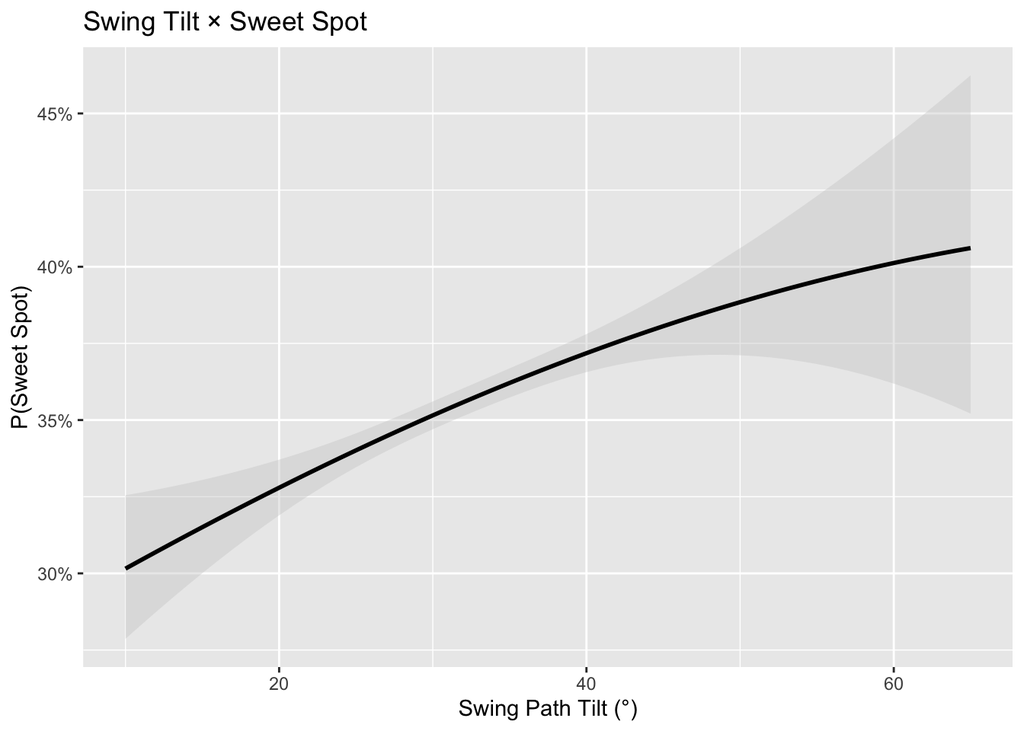

```r
m_sweet <- glm(sweet_spot ~ swing_path_tilt + I(swing_path_tilt^2),
                family = binomial, data = dat)

m_sweet_z <- glm(sweet_spot ~ swing_path_tilt*plate_z_bin + I(swing_path_tilt^2)*plate_z_bin,
                 family = binomial, data = dat)

pred_ci(m_sweet, nd_tilt) |>
  ggplot(aes(swing_path_tilt, fit)) +
  geom_ribbon(aes(ymin=lwr, ymax=upr), fill="grey80", alpha=.4) +
  geom_line(linewidth=1) +
  scale_y_continuous(labels=scales::percent) +
  labs(title="Swing Tilt × Sweet Spot", x="Swing Path Tilt (°)", y="P(Sweet Spot)")
```

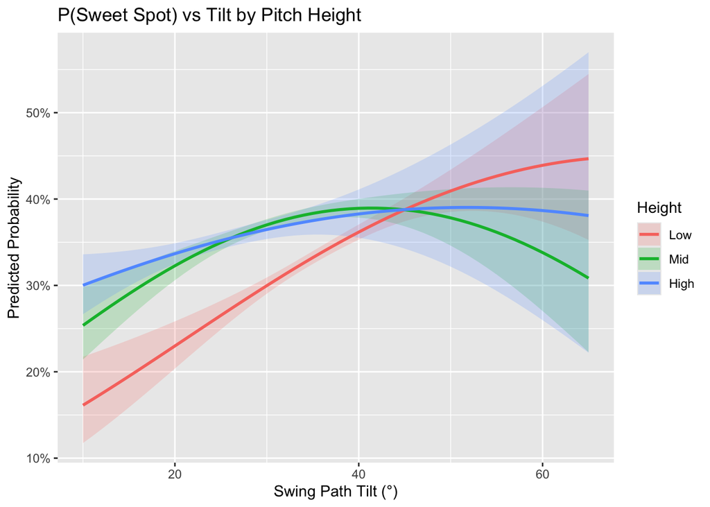

```r
pred_ci(m_sweet_z, nd_tilt_z) |>
  ggplot(aes(swing_path_tilt, fit, color=plate_z_bin, fill=plate_z_bin)) +
  geom_ribbon(aes(ymin=lwr, ymax=upr), alpha=.2, colour=NA) +
  geom_line(linewidth=1) +
  scale_y_continuous(labels=scales::percent) +
  labs(title="P(Sweet Spot) vs Tilt by Pitch Height", x="Swing Path Tilt (°)", y="Predicted Probability", color="Height", fill="Height")
```

#### 3.3.2 Hard-Hit Rate

The baseline model shows an inverted-U pattern between tilt and Hard–Hit probability.

After adding pitch height, zone differences became clear:

- **Low pitches**: benefit from higher tilt.
- **Mid pitches**: strongest effect around 30° tilt.
- **High pitches**: performance drops at steep angles.

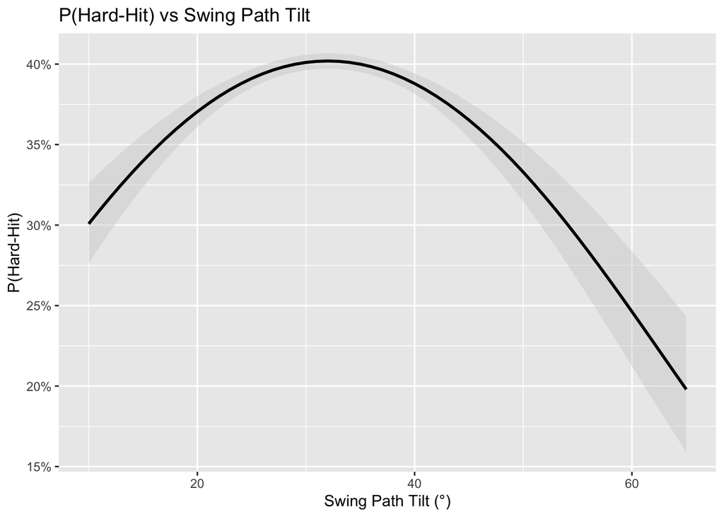

```r
m_hard <- glm(hard_hit ~ swing_path_tilt + I(swing_path_tilt^2),
              family = binomial, data = dat)

m_hard_z  <- glm(hard_hit ~ swing_path_tilt*plate_z_bin + I(swing_path_tilt^2)*plate_z_bin,
                 family = binomial, data = dat)

pred_ci(m_hard, nd_tilt) |>
  ggplot(aes(swing_path_tilt, fit)) +
  geom_ribbon(aes(ymin=lwr, ymax=upr), fill="grey80", alpha=.4) +
  geom_line(linewidth=1) +
  scale_y_continuous(labels=scales::percent) +
  labs(title="P(Hard-Hit) vs Swing Path Tilt", x="Swing Path Tilt (°)", y="P(Hard-Hit)")
```

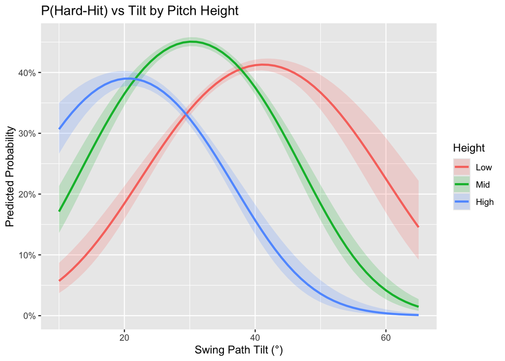

```r
pred_ci(m_hard_z, nd_tilt_z) |>
  ggplot(aes(swing_path_tilt, fit, color=plate_z_bin, fill=plate_z_bin)) +
  geom_ribbon(aes(ymin=lwr, ymax=upr), alpha=.2, colour=NA) +
  geom_line(linewidth=1) +
  scale_y_continuous(labels=scales::percent) +
  labs(title="P(Hard-Hit) vs Tilt by Pitch Height", x="Swing Path Tilt (°)", y="Predicted Probability", color="Height", fill="Height")
```

#### 3.3.3 Expected wOBA

The tilt-only model shows a mild rise then decline beyond 50°.

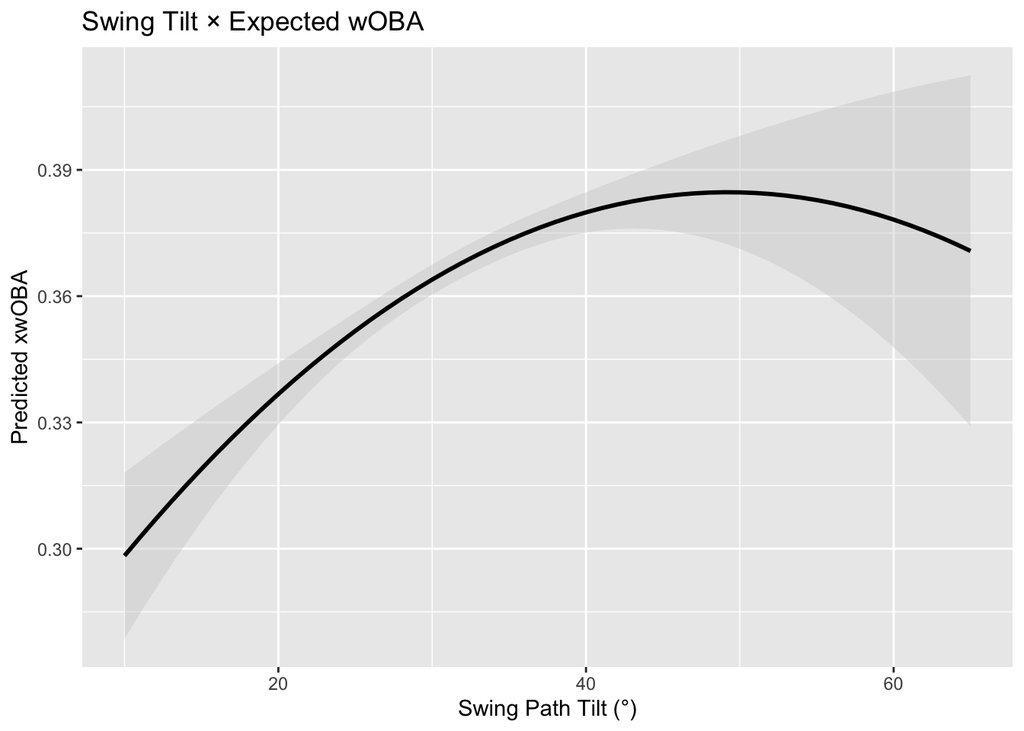

```r
m_woba <- lm(estimated_woba_using_speedangle ~ swing_path_tilt + I(swing_path_tilt^2),
              data = dat)

m_woba_z  <- lm(estimated_woba_using_speedangle ~ swing_path_tilt*plate_z_bin + I(swing_path_tilt^2)*plate_z_bin, data = dat)

pred_ci(m_woba, nd_tilt) |>
  ggplot(aes(swing_path_tilt, fit)) +
  geom_ribbon(aes(ymin=lwr, ymax=upr), fill="grey80", alpha=.4) +
  geom_line(linewidth=1) +
  labs(title="Swing Tilt × Expected wOBA", x="Swing Path Tilt (°)", y="Predicted xwOBA")
```

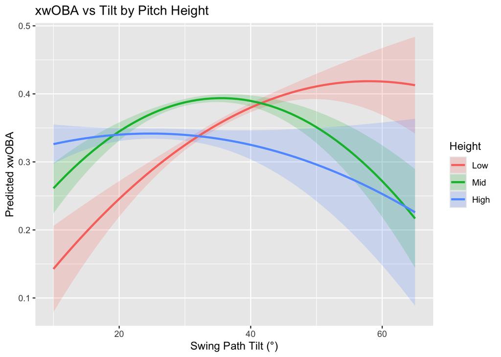

```r
pred_ci(m_woba_z, nd_tilt_z) |>
  ggplot(aes(swing_path_tilt, fit, color=plate_z_bin, fill=plate_z_bin)) +
  geom_ribbon(aes(ymin=lwr, ymax=upr), alpha=.2, colour=NA) +
  geom_line(linewidth=1) +
  labs(title="xwOBA vs Tilt by Pitch Height", x="Swing Path Tilt (°)", y="Predicted xwOBA", color="Height", fill="Height")
```

### 3.4 Evaluation

Model quality was assessed using Pseudo R², AUC, R², and RMSE.

Though overall explanatory power remains modest (expected for Statcast data), the consistent direction across models supports that swing–pitch interaction meaningfully shapes contact quality.

```r
model_key <- function(m) paste(class(m)[1], deparse(stats::formula(m)), collapse = " ")

glm_truth_pred <- function(m) {
  mf <- stats::model.frame(m)
  y  <- stats::model.response(mf)
  p  <- stats::predict(m, type = "response")
  y  <- if (is.logical(y)) as.integer(y) else
        if (is.factor(y)) as.integer(y) - 1 else as.numeric(y)
  tibble(truth = y, .pred = p) |> tidyr::drop_na()
}

auc_pROC <- function(truth, pred) {
  if (length(unique(truth)) < 2) return(NA_real_)
  if (sd(pred) == 0) return(NA_real_)
  out <- tryCatch({
    pROC::auc(truth, pred, quiet = TRUE)
  }, error = function(e) NA_real_)
  as.numeric(out)
}

evaluate_models <- function(...) {
  ms   <- list(...)
  keys <- vapply(ms, model_key, character(1))
  ms   <- ms[!duplicated(keys)]
  keys <- keys[!duplicated(keys)]

  map2_dfr(ms, keys, function(m, key) {
    typ <- class(m)[1]
    if (typ == "glm") {
      pr2 <- 1 - (m$deviance / m$null.deviance)
      df  <- glm_truth_pred(m)
      auc_val <- auc_pROC(df$truth, df$.pred)
      tibble(Model = key, Type = typ,
             R2 = NA_real_, RMSE = NA_real_,
             PseudoR2 = pr2, AUC = auc_val)
    } else { # lm
      r2   <- summary(m)$r.squared
      rmse <- sqrt(mean(residuals(m)^2))
      tibble(Model = key, Type = typ,
             R2 = r2, RMSE = rmse,
             PseudoR2 = NA_real_, AUC = NA_real_)
    }
  })
}

evaluate_models(m_sweet, m_sweet_z, m_hard, m_hard_z, m_woba, m_woba_z)
```

```
## # A tibble: 6 × 6
##   Model                                    Type        R2   RMSE PseudoR2    AUC
##   <chr>                                    <chr>    <dbl>  <dbl>    <dbl>  <dbl>
## 1 glm sweet_spot ~ swing_path_tilt + I(sw… glm   NA       NA      7.14e-4  0.518
## 2 glm sweet_spot ~ swing_path_tilt * plat… glm   NA       NA      2.83e-3  0.535
## 3 glm hard_hit ~ swing_path_tilt + I(swin… glm   NA       NA      8.28e-4  0.512
## 4 glm hard_hit ~ swing_path_tilt * plate_… glm   NA       NA      9.61e-3  0.559
## 5 lm estimated_woba_using_speedangle ~ sw… lm     0.00136  0.375 NA       NA
## 6 lm estimated_woba_using_speedangle ~ sw… lm     0.00533  0.375 NA       NA
```

### 3.5 Conclusion

This study examined how swing path tilt influences three indicators of hitting quality — *Sweet Spot Rate*, *Hard–Hit Rate*, and *Expected wOBA* — and how this relationship varies with pitch height.

Although the models exhibit modest explanatory power (a typical feature of Statcast-level variance), the consistent directional patterns support the biomechanical principle that effective hitting depends on matching swing trajectory to pitch location.

These findings highlight the importance of dynamic swing adjustment and offer quantitative evidence linking swing mechanics to batted-ball outcomes.

Future work could extend this analysis by incorporating pitch type, spin rate, and batter–pitcher handedness to further contextualize how hitters optimize their mechanics against varying pitch profiles.